# Process Pupillometry Data

## Information

This script was developed by Jacie R. McHaney and was last updated 5/26/23 This script processes data that has been exported from SR Research’s DataViewer Software. Data must be in a .txt format from DataViewer with the following columns: `IP_INDEX IP_LABEL RECORDING_SESSION_LABEL TRIAL_INDEX EYE_TRACKED IP_DURATION LEFT_IN_BLINK LEFT_IN_SACCADE LEFT_PUPIL_SIZE`

### Load libraries and clear variables

```r
rm(list = ls())

library(tidyverse)
library(rstatix)
library(naniar)
library(zoo)
```

### Set up processing pathways and parameters

It is very important to set the parameters in this section to be specific to your dataset and research question.

```r
#location of exported txt files
inpath <- getwd()

#eyelink exported data file
file <- read.table(paste(inpath, '/pupil_sample_quicksin.txt', sep = ''), header = TRUE, sep = '\t')

### parameters
today <- Sys.Date()

outpath <- paste(inpath, '/processed_pup_data', sep = '')
if(file.exists(outpath)==FALSE){
  dir.create(outpath)
}
outname <- paste('processed_data_', today, '.csv', sep = '')

fs <- 50; #sampling rate of the exported data
spoint <- 1000/fs
pre.pad <- 60 #how much to pad before blinks in ms
post.pad  <- 160 #after blink pad in ms
sacc.pad <- 60 #how much to interp on either side of saccade in ms
baseline <- 1000 #how long of a baseline period do you want in ms

#attach functions
source(paste(inpath,'/blink_interp_dv.R', sep = '')) #where are the scripts and function scripts located
source(paste(inpath,'/sacc_interp_dv.R', sep = '')) #where are the scripts and function scripts located
```

## Prepare the data for analysis

```r
#make sure all data was left-eye tracked (or right)
unique(file$EYE_TRACKED)
```

```
## [1] "Left"
```

```r
trim <- file %>%
  select(-c(EYE_TRACKED,IP_INDEX,IP_LABEL)) %>% #remove unnecessary columns
  separate(RECORDING_SESSION_LABEL, into = c('subj',NA), sep = '_') %>% #create subject column
  rename(runTrial = TRIAL_INDEX,
         pupil = LEFT_PUPIL_SIZE,
         blink = LEFT_IN_BLINK,
         saccade = LEFT_IN_SACCADE) %>%
  mutate(subj = as.factor(subj))

#2. find lower bound of samples for trials and create time vec
nsamps <- min(trim$IP_DURATION) #in ms
spTrial <- round((nsamps/1000)*fs)
maxtime <- (spTrial*20)-1000 #in ms
tvec <- seq(-980,maxtime,spoint) #this creates the time vector based on your sampling rate and length of trial
```

## Reject “bad” pupil trials

These can be from a number of things, (e.g., too many blinks, lost tracking, etc) Here, the rejection threshold for blinks is 15% of the trial detected as a blink, which is based on prior literature.

```r
#1. trim so each trial is same length
data.now <- trim %>%
  select(-IP_DURATION) %>%
  group_by(subj,runTrial) %>%
  slice_head(n = spTrial)

data.now %>% group_by(subj,runTrial) %>% count() #this just confirms that it worked and that all trials are the same
```

```
## # A tibble: 360 × 3
## # Groups:   subj, runTrial [360]
##    subj  runTrial     n
##    <fct>    <int> <int>
##  1 1001         1   415
##  2 1001         2   415
##  3 1001         3   415
##  4 1001         4   415
##  5 1001         5   415
##  6 1001         6   415
##  7 1001         7   415
##  8 1001         8   415
##  9 1001         9   415
## 10 1001        10   415
## # … with 350 more rows
```

```r
#2. label bad trials defined as >15% of the samples were detected as a blink.
bad.trials <- data.now %>%
  group_by(subj,runTrial) %>%
  transmute(percBlink = sum(blink)/spTrial) %>%
  distinct() %>%
  subset(percBlink > .15)

#3. need to now exclude these bad trials.
data.good <- data.now %>%
  anti_join(bad.trials, by = c('subj','runTrial')) %>%
  group_by(subj,runTrial) %>%
  mutate(Time = tvec,
         sp = seq(1,spTrial))
```

## Linearly Interpolate blinks with custom function

```r
blink.dat <- blink_interp_dv(data.good,spoint,fs, pre.pad, post.pad)
```

## Now linearly interpolate saccades

```r
fixed.dat <- sacc_interp_dv(blink.dat, spoint, fs, sacc.pad, spTrial)
```

### Confirm that interpolation worked using a single subject

You must change the subject number here to reflect one of your subject’s

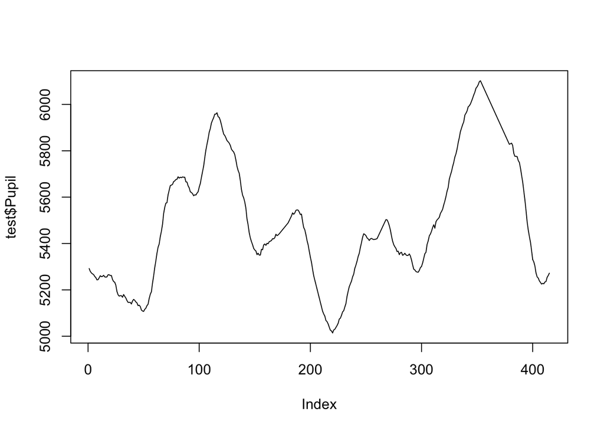

```r
#check a single trial
test <- subset(fixed.dat, subj == '1001' & runTrial == 1)
plot(test$Pupil, type = 'l')
```

## Baseline normalize your data

This takes the mean pupil response of your baseline period and normalizes the pupil response on a trial by trial basis to the mean of the baseline.

```r
bsl.corr <- fixed.dat %>%
  mutate(Event = as.factor(case_when(Time < 0 ~ 'Baseline',
                           TRUE ~ 'Stim'))) %>%
  subset(Event == 'Baseline') %>%
  select(subj,runTrial,Pupil) %>%
  group_by(subj,runTrial) %>%
  get_summary_stats(Pupil, type = 'mean') %>%
  rename(Basemean = mean) %>%
  select(-c(variable,n)) %>%
  left_join(fixed.dat, by = c('subj','runTrial')) %>%
  mutate(Pupil_corr = (Pupil - Basemean)/Basemean)
```

# Save your data

```r
#prep and save
final <- bsl.corr %>%
  select(-c(Pupil,Basemean)) %>%
  rename(Pupil=Pupil_corr)

write.csv(final, paste(outpath, '/', outname, sep = ''), row.names = FALSE)
```